# Not within spitting distance: salivary immunoassays of estradiol have subpar validity for cycle phase

LH_test

**More**

Participants were also provided with and trained to use the Clearblue Easy Fertility Monitor (Inverness Medical Innovations, Inc., Waltham, Massachusetts) (www.clearblueeasy.com). The fertility monitor was originally developed to assist women in becoming pregnant by helping them to identify their fertile window through measurement of both estrone- 3-glucuronide (E3G) and LH in urine as described in greater detail elsewhere (13). Briefly, the monitor is synchronized to a woman’s cycle and then is checked daily to see whether a test is requested. Between the sixth and the ninth days of a woman’s cycle (depending on her cycle length history), the monitor begins to request daily tests for 10 days. On test days, the woman briefly submerges a test stick in her first- morning urine and then inserts the test stick into the monitor. The test stick has a nitrocellulose strip with an anti-LH antibody zone and an E3G conjugate zone. The monitor optically reads the level of E3G and LH in the urine by the intensity of the lines in the corresponding zones (13). Each day, the monitor assigns the woman to low, high, or peak fertility on the basis of her E3G and LH levels. Thus, unlike home LH test sticks, the monitor provides informa- tion to help anticipate the LH surge.

**More**

All participants received LH kits. Each kit consisted of sterilized urine cups and 10 LH tests. Women were instructed to conduct the tests from the 10th until the 20th day of the cycle or until a positive result was obtained.

**More**

highly sensitive (10mIU) LH urine ovulation test strips from MedNet GmbH. Participants started LH-testing after menstruation (around reverse cycle day 21) and continued until a rise of LH (positive tests) was observed and a minimum of two days after the tests were negative again (as suggested by Roney, 2018b). Participants were provided with a minimum of ten LH tests each and provided daily pictures of the tests to the investigators for confir- mation. LH results were used to allow flexible scheduling in case LH test results differed from the scheduling based on counting (see supplementary material for details).

**More**

highly sensitive (10 mIU/ml) urine ovulation test strips from purbay®, which measure the luteinizing hormone (LH). These LH-tests had to be done at home at the estimated day of ovulation and the four days prior to that and results were self- reported by the participants.

**More**

To maximize the likelihood of detecting surges in LH, we fol- lowed the standardized LH testing procedure in Blake et al. (2016b). All participants used commercially available urinary LH tests (Blue Cross Bio-Medical Co. LTD, CE/FDA Registered) and tested until a positive surge was detected. Wave 1 participants tested until a positive result was reported (a maximum of 10days) and Wave 2 tested for 11 continuous days, even if a surge was reported ear- lier. We instructed participants to test between 1000 h and 2000 h and report the result to the research team via SMS or email. The repeated design of the study required that all participants attended one fertile and one non-fertile laboratory session. Hence, all participants included here detected a LH surge and thus had ovulatory cycles. Participants who did not record a surge in LH were not eligible for inclusion in the study (see Blake et al., 2016b for full details of the sampling procedure).

Sample

Age

27.3±8.21

NA

21.5±3.29

NA

23.1±3.28

23.2±3.45

22.7±4.87

NA

In Relationship

25%

NA

36%

NA

47%

48%

53%

NA

Cycle length

28.8±4.10

27.6±5.06

29.7±6.73

28.2±2.99

30.0±4.75

29.5±6.54

29.2±2.39

28.8±3.71

Women

259

43

384

102

257

157

60

33

Cycles

509

122

907

102

454

398

86

33

Days

4072

2367

2394

2233

1028

628

120

66

% women no LH surge

43/257 (17%)

NA

NA

25/99 (25%)

50/238 (21%)

10/124 (8%)

0/58 (0%)

NA

% cycles no LH surge

141/481 (29%)

NA

NA

25/99 (25%)

134/377 (36%)

59/240 (25%)

26/84 (31%)

NA

Usable n women

257

42

360

99

238

156

58

31

Usable n days

3682

1121

1664

1550

778

537

114

57

Descriptive statistics

Distribution

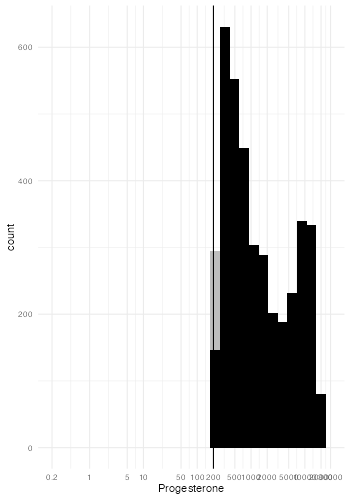

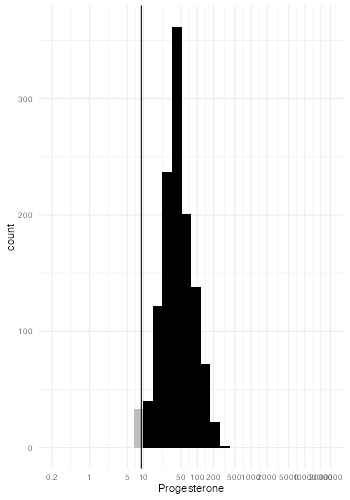

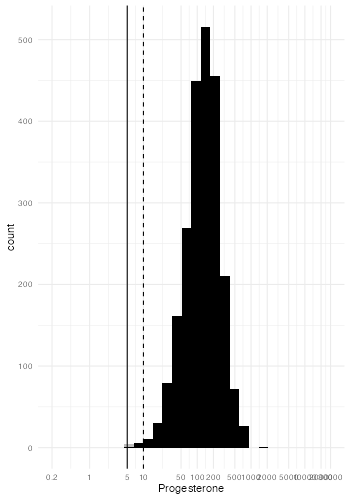

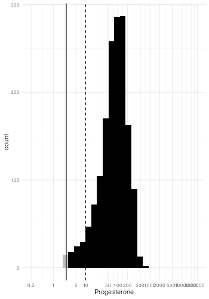

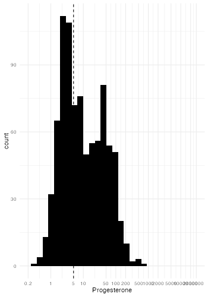

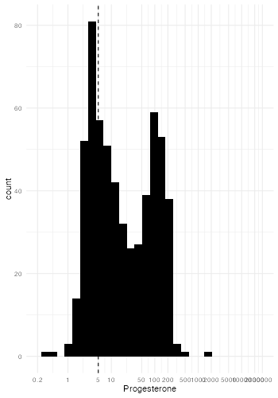

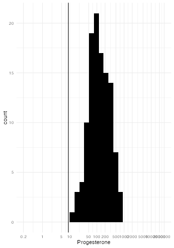

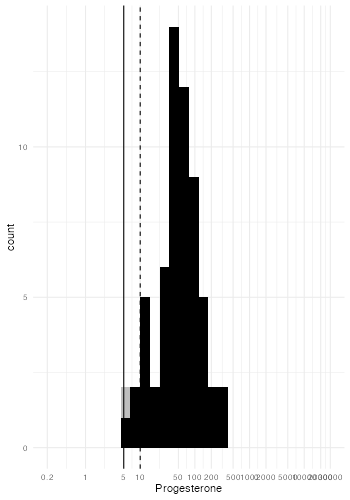

logmean

7.24

3.76

4.81

4.26

2.26

2.87

4.77

3.88

logsd

1.36

0.67

0.76

1.03

1.49

1.59

0.88

0.91

missing

171 (4%)

1139 (48%)

103 (4%)

654 (29%)

160 (16%)

47 (7%)

6 (5%)

5 (8%)

outliers

0 (0%)

0 (0%)

1 (0%)

0 (0%)

0 (0%)

0 (0%)

0 (0%)

0 (0%)

censored

147 (4%)

33 (1%)

4 (0%)

15 (1%)

0 (0%)

0 (0%)

0 (0%)

1 (2%)

mean

3437.53

53.74

158.54

106.34

27.97

53.72

170.22

69.62

sd

4683.28

39.21

121.31

88.95

52.67

91.17

155.69

62.44

median

1000.00

40.36

130.17

85.60

7.45

13.50

112.00

49.28

mad

1037.82

22.78

90.32

71.63

8.55

16.12

91.11

39.70

range

200.00, 27700.00

9.14, 310.00

5.00, 1859.40

2.50, 875.96

0.22, 671.77

0.26, 1480.00

14.13, 748.71

5.00, 293.46

Interindividual differences

var_id_loo

0.02 [0.01;0.02]

0.09 [0.06;0.12]

0.32 [0.28;0.36]

0.45 [0.41;0.48]

-0.00 [-0.01;-0.00]

-0.01 [-0.01;-0.00]

-0.00 [-0.06;0.04]

0.10 [-0.06;0.23]

var_cycle_loo

0.02 [0.01;0.02]

0.10 [0.07;0.14]

0.32 [0.28;0.36]

NA

-0.00 [-0.01;0.00]

-0.01 [-0.02;-0.01]

-0.03 [-0.08;0.02]

NA

var_id

0.30 [0.23;0.37] (5%)

0.19 [0.06;0.29] (8%)

0.49 [0.43;0.55] (39%)

0.73 [0.62;0.85] (49%)

0.10 [0.00;0.27] (1%)

0.11 [0.00;0.28] (1%)

0.25 [0.01;0.54] (10%)

0.58 [0.13;0.96] (37%)

var_cycle

0.05 [0.00;0.13] (0%)

0.19 [0.10;0.28] (8%)

0.18 [0.04;0.27] (6%)

NA

0.27 [0.02;0.53] (4%)

0.09 [0.00;0.25] (0%)

0.20 [0.01;0.50] (7%)

NA

var_resid

1.37 [1.34;1.41] (95%)

0.63 [0.61;0.66] (84%)

0.58 [0.56;0.61] (55%)

0.73 [0.70;0.76] (51%)

1.46 [1.38;1.55] (95%)

1.59 [1.50;1.69] (99%)

0.83 [0.69;0.98] (84%)

0.75 [0.56;1.00] (63%)

Validity (Forward counting)

r_fc_stirn

-0.35 [-0.37;-0.32]

-0.32 [-0.37;-0.27]

-0.18 [-0.23;-0.13]

-0.07 [-0.12;-0.02]

-0.32 [-0.38;-0.25]

-0.54 [-0.61;-0.46]

-0.13 [-0.31; 0.05]

-0.20 [-0.44; 0.06]

r_log_fc_stirn

-0.34 [-0.37;-0.31]

-0.33 [-0.38;-0.27]

-0.17 [-0.22;-0.12]

-0.05 [-0.10;-0.00]

-0.52 [-0.57;-0.47]

-0.65 [-0.71;-0.59]

-0.11 [-0.29; 0.07]

-0.19 [-0.43; 0.08]

r_diff_fc_stirn

-0.37 [-0.40;-0.34]

-0.34 [-0.39;-0.29]

-0.23 [-0.28;-0.19]

-0.18 [-0.23;-0.13]

-0.35 [-0.41;-0.29]

-0.59 [-0.65;-0.52]

-0.09 [-0.27; 0.10]

-0.06 [-0.32; 0.20]

r_log_diff_fc_stirn

-0.36 [-0.39;-0.33]

-0.35 [-0.40;-0.29]

-0.25 [-0.29;-0.20]

-0.18 [-0.22;-0.13]

-0.56 [-0.60;-0.51]

-0.70 [-0.75;-0.65]

-0.03 [-0.22; 0.15]

-0.10 [-0.35; 0.17]

r_loo_fc

0.72 [0.70;0.74]

0.48 [0.43;0.52]

0.26 [0.20;0.31]

0.08 [NaN;0.20]

0.62 [0.57;0.66]

0.70 [0.63;0.74]

NaN [NaN;0.25]

NaN [NaN;NaN]

r_fc_imputed

0.72 [ 0.71; 0.74]

0.48 [ 0.44; 0.53]

0.29 [ 0.24; 0.34]

0.19 [ 0.14; 0.23]

0.62 [ 0.57; 0.66]

0.67 [ 0.61; 0.72]

0.20 [ 0.02; 0.37]

0.16 [-0.11; 0.40]

r_diff_fc_imputed

0.76 [ 0.75; 0.78]

0.51 [ 0.47; 0.55]

0.38 [ 0.33; 0.42]

0.37 [ 0.33; 0.42]

0.64 [ 0.60; 0.68]

0.70 [ 0.64; 0.75]

0.02 [-0.16; 0.21]

0.09 [-0.17; 0.34]

sd_fc_imputed

1.07 (84%)

1.06 (82%)

1.13 (92%)

0.96 (67%)

1.11 (89%)

1.05 (81%)

0.92 (61%)

1.14 (95%)

r_diff_fc_imputed_rr

0.79 [ 0.78; 0.80]

0.55 [ 0.50; 0.59]

0.39 [ 0.35; 0.43]

0.44 [ 0.39; 0.49]

0.66 [ 0.62; 0.70]

0.74 [ 0.68; 0.78]

0.03 [-0.20; 0.26]

0.09 [-0.18; 0.35]

r_within_fc_imputed

0.79 [ 0.77; 0.80]

0.53 [ 0.49; 0.57]

0.41 [ 0.36; 0.46]

0.40 [ 0.36; 0.44]

0.70 [ 0.66; 0.74]

0.75 [ 0.69; 0.80]

0.04 [-0.22; 0.30]

0.12 [-0.27; 0.48]

r_within_fc_imputed_rr

0.81 [ 0.80; 0.82]

0.57 [ 0.53; 0.61]

0.41 [ 0.36; 0.46]

0.49 [ 0.44; 0.53]

0.69 [ 0.65; 0.73]

0.74 [ 0.68; 0.79]

0.05 [-0.30; 0.39]

0.12 [-0.26; 0.46]

plot_fc

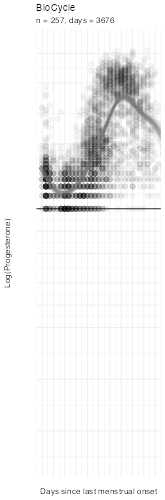

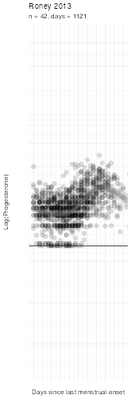

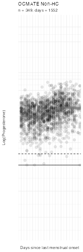

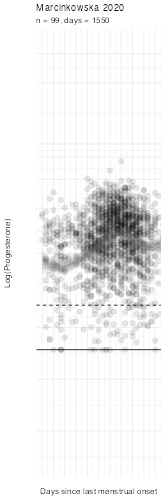

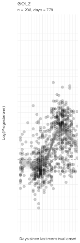

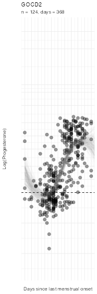

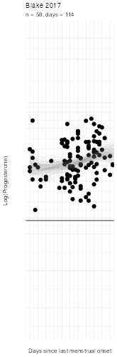

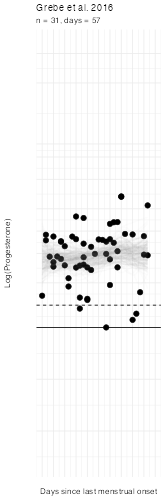

r_fc

0.74 [0.74;0.75]

0.53 [0.49;0.56]

0.31 [0.27;0.34]

0.30 [0.27;0.33]

0.63 [0.60;0.66]

0.71 [0.68;0.74]

0.26 [0.08;0.40]

0.20 [0.03;0.37]

Validity (Backward counting)

r_bc_stirn

-0.40 [-0.43;-0.37]

-0.36 [-0.41;-0.31]

-0.25 [-0.32;-0.18]

-0.15 [-0.20;-0.10]

-0.30 [-0.36;-0.23]

-0.42 [-0.49;-0.35]

-0.21 [-0.38;-0.02]

NA

r_log_bc_stirn

-0.41 [-0.44;-0.38]

-0.36 [-0.41;-0.30]

-0.27 [-0.33;-0.20]

-0.13 [-0.18;-0.08]

-0.51 [-0.56;-0.45]

-0.67 [-0.72;-0.62]

-0.17 [-0.35; 0.01]

NA

r_diff_bc_stirn

-0.42 [-0.45;-0.40]

-0.39 [-0.44;-0.34]

-0.31 [-0.37;-0.24]

-0.27 [-0.32;-0.22]

-0.37 [-0.43;-0.31]

-0.53 [-0.58;-0.46]

-0.22 [-0.39;-0.03]

NA

r_log_diff_bc_stirn

-0.43 [-0.46;-0.40]

-0.39 [-0.44;-0.34]

-0.34 [-0.40;-0.28]

-0.26 [-0.31;-0.21]

-0.57 [-0.61;-0.52]

-0.74 [-0.78;-0.70]

-0.18 [-0.35; 0.01]

NA

r_loo_bc

0.83 [0.81;0.84]

0.47 [0.42;0.52]

0.37 [0.29;0.43]

0.23 [0.13;0.29]

0.67 [0.62;0.71]

0.73 [0.68;0.77]

NaN [NaN;0.26]

NA

r_bc_imputed

0.83 [ 0.82; 0.84]

0.44 [ 0.40; 0.49]

0.40 [ 0.34; 0.46]

0.28 [ 0.24; 0.33]

0.67 [ 0.63; 0.71]

0.74 [ 0.69; 0.77]

0.25 [ 0.07; 0.42]

NA

r_diff_bc_imputed

0.86 [ 0.85; 0.87]

0.49 [ 0.45; 0.54]

0.48 [ 0.43; 0.54]

0.48 [ 0.44; 0.52]

0.70 [ 0.66; 0.74]

0.77 [ 0.74; 0.81]

0.11 [-0.07; 0.30]

NA

sd_bc_imputed

1.17 (87%)

1.20 (91%)

1.20 (91%)

1.03 (66%)

1.26 (101%)

1.27 (101%)

1.15 (83%)

NA

r_diff_bc_imputed_rr

0.88 [ 0.87; 0.88]

0.51 [ 0.47; 0.56]

0.50 [ 0.45; 0.56]

0.56 [ 0.52; 0.60]

0.70 [ 0.66; 0.74]

0.77 [ 0.73; 0.80]

0.13 [-0.08; 0.32]

NA

r_within_bc_imputed

0.88 [ 0.87; 0.89]

0.51 [ 0.46; 0.55]

0.52 [ 0.45; 0.58]

0.50 [ 0.46; 0.54]

0.77 [ 0.73; 0.80]

0.82 [ 0.78; 0.85]

0.17 [-0.10; 0.42]

NA

r_within_bc_imputed_rr

0.89 [ 0.88; 0.90]

0.52 [ 0.48; 0.57]

0.51 [ 0.44; 0.57]

0.58 [ 0.54; 0.62]

0.74 [ 0.70; 0.77]

0.78 [ 0.74; 0.82]

0.18 [-0.11; 0.44]

NA

plot_bc

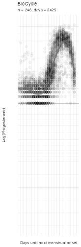

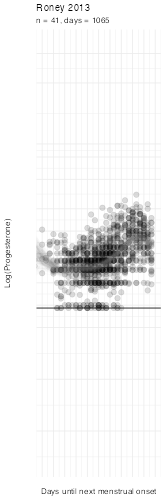

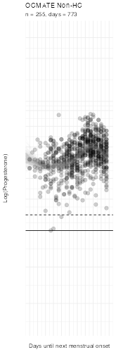

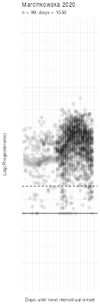

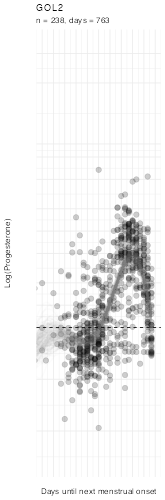

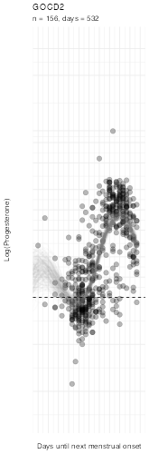

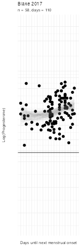

NA

r_bc

0.84 [0.83;0.84]

0.52 [0.48;0.55]

0.40 [0.36;0.44]

0.36 [0.33;0.39]

0.68 [0.66;0.71]

0.75 [0.72;0.77]

0.27 [0.08;0.41]

NA

Validity (LH)

r_prob_lh

-0.37 [-0.40;-0.33]

NA

NA

-0.16 [-0.22;-0.10]

-0.30 [-0.37;-0.22]

-0.38 [-0.46;-0.29]

-0.08 [-0.29; 0.13]

NA

r_log_prob_lh

-0.30 [-0.34;-0.26]

NA

NA

-0.13 [-0.18;-0.07]

-0.37 [-0.44;-0.30]

-0.60 [-0.66;-0.54]

-0.10 [-0.30; 0.12]

NA

r_diff_prob_lh

-0.36 [-0.39;-0.33]

NA

NA

-0.20 [-0.25;-0.14]

-0.33 [-0.41;-0.26]

-0.46 [-0.54;-0.39]

-0.15 [-0.35; 0.06]

NA

r_log_diff_prob_lh

-0.30 [-0.33;-0.26]

NA

NA

-0.19 [-0.24;-0.13]

-0.43 [-0.49;-0.36]

-0.67 [-0.72;-0.61]

-0.16 [-0.35; 0.05]

NA

r_loo_lh

0.87 [0.85;0.88]

NA

NA

0.24 [0.13;0.31]

0.68 [0.62;0.72]

0.69 [0.63;0.74]

NaN [NaN;0.21]

NA

r_lh_imputed

0.87 [ 0.86; 0.88]

NA

NA

0.31 [ 0.25; 0.36]

0.68 [ 0.63; 0.72]

0.62 [ 0.56; 0.68]

0.12 [-0.09; 0.32]

NA

r_diff_lh_imputed

0.88 [ 0.88; 0.89]

NA

NA

0.44 [ 0.39; 0.49]

0.72 [ 0.68; 0.76]

0.69 [ 0.63; 0.73]

0.11 [-0.10; 0.31]

NA

sd_lh_imputed

1.21 (82%)

NA

NA

1.10 (67%)

1.34 (100%)

1.09 (66%)

0.87 (42%)

NA

r_diff_lh_imputed_rr

0.90 [ 0.89; 0.91]

NA

NA

0.52 [ 0.46; 0.56]

0.72 [ 0.68; 0.76]

0.76 [ 0.71; 0.80]

0.17 [-0.15; 0.45]

NA

r_within_lh_imputed

0.90 [ 0.89; 0.91]

NA

NA

0.46 [ 0.42; 0.51]

0.76 [ 0.71; 0.80]

0.73 [ 0.67; 0.78]

0.23 [-0.13; 0.54]

NA

r_within_lh_imputed_rr

0.91 [ 0.91; 0.92]

NA

NA

0.55 [ 0.49; 0.59]

0.72 [ 0.67; 0.76]

0.75 [ 0.69; 0.80]

0.28 [-0.16; 0.62]

NA

plot_lh

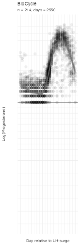

NA

NA

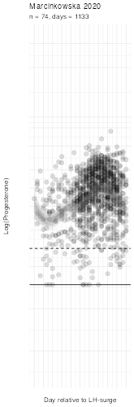

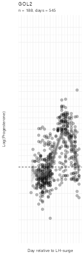

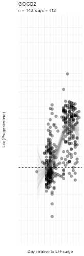

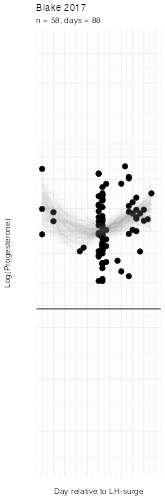

NA

r_lh

0.88 [0.87;0.88]

NA

NA

0.34 [0.31;0.37]

0.69 [0.65;0.71]

0.70 [0.67;0.73]

0.31 [0.12;0.46]

NA

### Estradiol & Progesterone (E2/P4)

```r
ratio_summary_table()
```

Estradiol and progesterone measures

Comparing salivary and serum measures on a variety of performance criteria

BioCycle

Blake '17

Jünger '18

Stern '21

Grebe '16

Marcinkowska '20

OCMATE

Roney '13

Measure

Dataset

BioCycle

Blake '17

Jünger '18

Stern '21

Grebe '16

Marcinkowska '20

OCMATE

Roney '13

Method

Serum Immunoassay

Salivary immunoassay (IBL)

Salivary Immunoassay

Salivary Immunoassay

Salivary Immunoassay

Salivary immunoassay (DRG)

Salivary Immunoassay

Salivary Immunoassay

Hormone

Estradiol & Progesterone

Estradiol & Progesterone

Estradiol & Progesterone

Estradiol & Progesterone

Estradiol & Progesterone

Estradiol & Progesterone

Estradiol & Progesterone

Estradiol & Progesterone

Sample size

Women

259

60

157

257

33

102

384

43

Cycles

509

86

398

454

33

102

907

122

Days

4072

120

628

1028

66

2233

2394

2367

Usable n

3682

114

512

777

57

1066

1664

1091

Relationship

plot_scatter

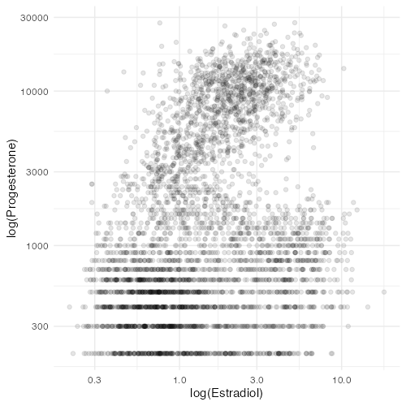

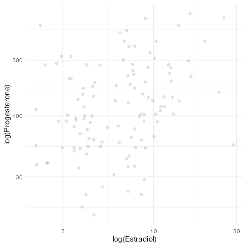

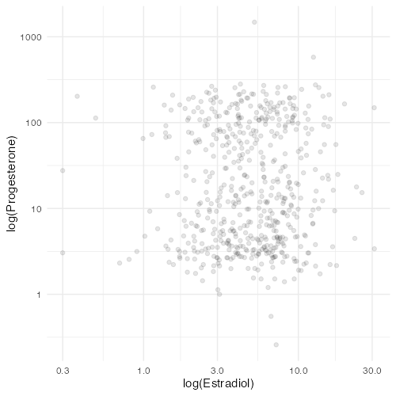

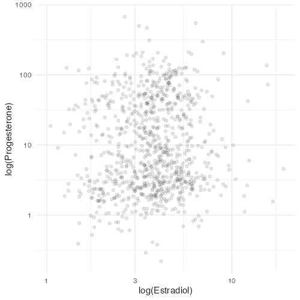

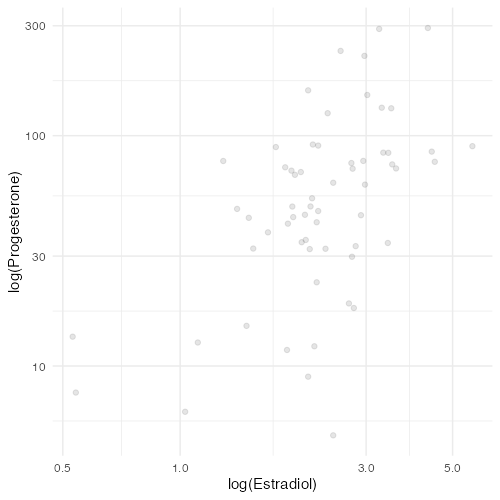

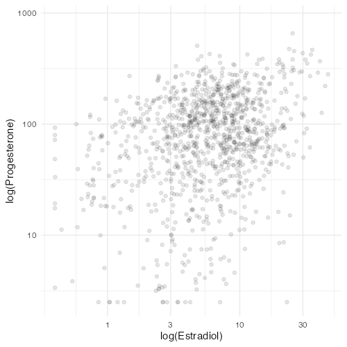

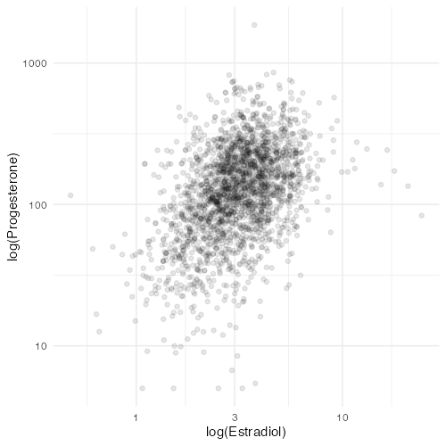

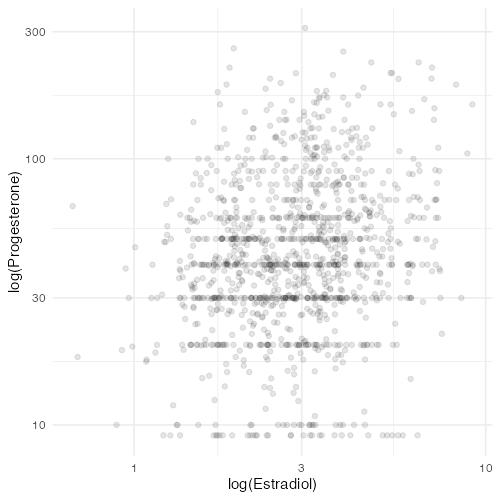

r_ep

0.14 [ 0.11; 0.17]

0.33 [ 0.16; 0.48]

0.02 [-0.06; 0.11]

0.02 [-0.05; 0.09]

0.45 [ 0.23; 0.63]

0.33 [ 0.28; 0.38]

0.27 [ 0.23; 0.30]

0.19 [ 0.14; 0.25]

r_log_ep

0.28 [ 0.25; 0.31]

0.30 [ 0.12; 0.46]

0.03 [-0.06; 0.11]

0.04 [-0.02; 0.11]

0.55 [ 0.35; 0.70]

0.31 [ 0.25; 0.36]

0.43 [ 0.40; 0.46]

0.19 [ 0.13; 0.24]

r_e_ratio

0.59 [ 0.57; 0.61]

0.30 [ 0.13; 0.46]

0.29 [ 0.21; 0.36]

0.29 [ 0.23; 0.35]

-0.07 [-0.32; 0.19]

0.17 [ 0.11; 0.23]

0.13 [ 0.09; 0.17]

0.35 [ 0.30; 0.40]

r_log_e_ratio

0.33 [ 0.30; 0.36]

0.35 [ 0.17; 0.50]

0.37 [ 0.29; 0.44]

0.24 [ 0.17; 0.30]

-0.10 [-0.34; 0.16]

0.47 [ 0.42; 0.52]

0.12 [ 0.08; 0.16]

0.41 [ 0.36; 0.46]

r_p_ratio

-0.35 [-0.38;-0.32]

-0.48 [-0.61;-0.33]

-0.26 [-0.33;-0.18]

-0.30 [-0.36;-0.24]

-0.46 [-0.64;-0.24]

-0.30 [-0.35;-0.25]

-0.43 [-0.46;-0.39]

-0.51 [-0.55;-0.47]

r_log_p_ratio

-0.81 [-0.82;-0.80]

-0.79 [-0.85;-0.71]

-0.92 [-0.93;-0.91]

-0.96 [-0.96;-0.95]

-0.88 [-0.93;-0.81]

-0.70 [-0.73;-0.66]

-0.84 [-0.85;-0.83]

-0.82 [-0.84;-0.80]

r_bc_ratio

0.53 [ 0.50; 0.55]

0.10 [-0.09; 0.28]

0.36 [ 0.28; 0.43]

0.33 [ 0.26; 0.39]

NA

0.14 [ 0.08; 0.20]

0.18 [ 0.11; 0.25]

0.20 [ 0.14; 0.26]

r_bc_log_ratio

0.61 [ 0.59; 0.63]

0.22 [ 0.03; 0.39]

0.65 [ 0.59; 0.69]

0.50 [ 0.45; 0.55]

NA

0.24 [ 0.19; 0.30]

0.30 [ 0.23; 0.36]

0.29 [ 0.24; 0.35]

r_erat_bc

0.63 [0.61;0.65]

0.06 [NaN;0.28]

0.68 [0.63;0.72]

0.50 [0.45;0.55]

NA

0.23 [0.16;0.29]

0.29 [0.21;0.34]

0.35 [0.29;0.39]

r_loo_bc

0.72 [0.70;0.74]

NaN [NaN;0.26]

0.69 [0.63;0.73]

0.51 [0.46;0.56]

NA

0.30 [0.23;0.35]

0.29 [0.21;0.34]

0.38 [0.32;0.42]

r_fc_ratio

0.41 [ 0.38; 0.44]

0.08 [-0.11; 0.26]

0.35 [ 0.25; 0.44]

0.36 [ 0.30; 0.42]

0.17 [-0.09; 0.42]

0.06 [ 0.00; 0.12]

0.10 [ 0.05; 0.15]

0.25 [ 0.20; 0.31]

r_fc_log_ratio

0.48 [ 0.46; 0.51]

0.17 [-0.02; 0.34]

0.61 [ 0.54; 0.67]

0.51 [ 0.46; 0.56]

0.26 [-0.00; 0.49]

0.14 [ 0.08; 0.20]

0.18 [ 0.14; 0.23]

0.31 [ 0.26; 0.37]

r_erat_fc

0.49 [0.46;0.51]

NaN [NaN;0.21]

0.64 [0.58;0.70]

0.52 [0.47;0.56]

NaN [NaN;0.34]

0.13 [NaN;0.18]

0.18 [0.12;0.22]

0.33 [0.28;0.38]

r_loo_fc

0.58 [0.55;0.60]

NaN [NaN;0.21]

0.65 [0.58;0.70]

0.52 [0.47;0.57]

NaN [NaN;0.33]

0.22 [0.15;0.28]

0.18 [0.12;0.22]

0.35 [0.30;0.39]

r_lh_ratio

0.53 [ 0.50; 0.56]

0.15 [-0.06; 0.35]

0.27 [ 0.17; 0.36]

0.22 [ 0.14; 0.30]

NA

0.12 [ 0.05; 0.18]

NA

NA

r_lh_log_ratio

0.60 [ 0.57; 0.62]

0.16 [-0.05; 0.36]

0.58 [ 0.51; 0.64]

0.38 [ 0.31; 0.45]

NA

0.21 [ 0.14; 0.28]

NA

NA

r_erat_lh

0.69 [0.66;0.71]

NaN [NaN;0.17]

0.61 [0.54;0.66]

0.37 [0.31;0.43]

NA

0.19 [0.08;0.25]

NA

NA

r_loo_lh

0.83 [0.81;0.85]

NaN [NaN;0.07]

0.62 [0.55;0.67]

0.38 [0.32;0.43]

NA

0.26 [0.18;0.32]

NA

NA

## Literature survey of estradiol assays

We performed the following search on SCOPUS. Journal: Psychoneuroendocrinology or Hormones and Behavior In Abstract Title or Keywords: Menstrual Cycle, Estradiol Limited to articles published 2017 or later.

```
( SRCTITLE ( psychoneuroendocrinology )  OR
  SRCTITLE ( hormones  AND  behavior )  AND
  TITLE-ABS-KEY ( estradiol )  AND
  TITLE-ABS-KEY ( menstrual  AND  cycle ) )
  AND  ( LIMIT-TO ( PUBYEAR ,  2022 )  OR
         LIMIT-TO ( PUBYEAR ,  2021 )  OR
         LIMIT-TO ( PUBYEAR ,  2020 )  OR
         LIMIT-TO ( PUBYEAR ,  2019 )  OR
         LIMIT-TO ( PUBYEAR ,  2018 )  OR
         LIMIT-TO ( PUBYEAR ,  2017 ) )
```

We then examined the fulltext of each article to code the following information:

- Is the article an empirical primary study related to menstrual cycle effects?
- Did they collect saliva, serum, urine, or something else?
- How did they assay estradiol?

```r
lit <- rio::import("lit_search_estradiol.xlsx")
lit <- lit %>% filter(Year >= 2017)
table(lit$`Menstrual Cycle`)
```

```
                                              no
                                               4
                                   not empirical
                                              10
                                      not humans
                                               1
sort of (between-subjects study on irregularity)
                                               1
                                             yes
                                              42
```

```r
litmc <- lit %>% filter(`Menstrual Cycle` == "yes")
table(litmc$`Source title`)
```

```
   Hormones and Behavior Psychoneuroendocrinology
                      15                       27
```

```r
saliva <- sum(litmc$`Body Fluid` == "Saliva")
table(litmc$`Body Fluid`)
```

```
app-based    Saliva     Serum     Urine
        1        38         2         1
```

```r
litsal <- litmc %>% filter(`Body Fluid` == "Saliva", coalesce(Notes,"") != "prog only")
table(litsal$`Source title`)
```

```
   Hormones and Behavior Psychoneuroendocrinology
                      15                       22
```

```r
table(litsal$Assay) %>% sort()
```

```
Diagnostic Systems Laboratories, Webster
                                       1
                             immunoassay
                                       1
                      LCMS/MS Kirschbaum
                                       1
           unclear (lab: SwisshealthMed)
                                       1
                   Demeditec Diagnostics
                                       2
                  Labor Diagnostika Nord
                                       2
                                     DRG
                                       6
                                     IBL
                                      11
                             Salimetrics
                                      12
```

We found N=58 papers. Of those, n=42 papers were empirical primary studies with at least one research question related to menstrual cycle changes within-women. Of those, n=38 collected saliva. The estradiol immunoassays studied here, i.e. Salimetrics, IBL, and DRG immunoassays accounted for 78% of the assays performed on salivary estradiol (*n*s=12,11,6). In most cases, the progesterone assay was done using kits from the same company.

```r
library(gtsummary)
litsal %>% select(Assay) %>% tbl_summary(sort = list(everything() ~ "frequency"))
```

| **Characteristic** | **N = 37**<sup>1</sup> |
| --- | --- |
| Assay |  |
| Salimetrics | 12 (32%) |
| IBL | 11 (30%) |
| DRG | 6 (16%) |
| Demeditec Diagnostics | 2 (5.4%) |
| Labor Diagnostika Nord | 2 (5.4%) |
| Diagnostic Systems Laboratories, Webster | 1 (2.7%) |
| immunoassay | 1 (2.7%) |
| LCMS/MS Kirschbaum | 1 (2.7%) |
| unclear (lab: SwisshealthMed) | 1 (2.7%) |

<sup>1</sup> n (%)

**List of papers**

```r
lit %>% select(Authors, Title, `Source title`, DOI, `Menstrual Cycle`, `Body Fluid`, `Assay`, Notes) %>% gt()
```

| Authors | Title | Source title | DOI | Menstrual Cycle | Body Fluid | Assay | Notes |
| --- | --- | --- | --- | --- | --- | --- | --- |
| Wang H., Li J., Chen L., He L. | Do women's natural hormonal fluctuations modulate prosociality? A within-subject analysis | Psychoneuroendocrinology | 10.1016/j.psyneuen.2022.105663 | yes | Saliva | DRG | NA |
| Marful A., Paolieri D., Bernal A. | Sex, menstrual cycle, and hormonal contraceptives influences on global–local processing | Psychoneuroendocrinology | 10.1016/j.psyneuen.2021.105430 | yes | Saliva | Labor Diagnostika Nord | NA |
| Rehbein E., Kogler L., Hornung J., Morawetz C., Bayer J., Krylova M., Sundström-Poromaa I., Derntl B. | Estradiol administration modulates neural emotion regulation | Psychoneuroendocrinology | 10.1016/j.psyneuen.2021.105425 | no | Serum | immunoassay | NA |
| Strojny J., Domes G., Fischbacher U., von Dawans B. | The modulation of social behavior and empathy via oral contraceptives and female sex hormones | Psychoneuroendocrinology | 10.1016/j.psyneuen.2021.105250 | yes | Saliva | Demeditec Diagnostics | NA |
| Gloe L.M., Kashy D.A., Jacobs E.G., Klump K.L., Moser J.S. | Examining the role of ovarian hormones in the association between worry and working memory across the menstrual cycle | Psychoneuroendocrinology | 10.1016/j.psyneuen.2021.105285 | yes | Saliva | Salimetrics | NA |
| Gordon J.L., Halleran M., Beshai S., Eisenlohr-Moul T.A., Frederick J., Campbell T.S. | Endocrine and psychosocial moderators of mindfulness-based stress reduction for the prevention of perimenopausal depressive symptoms: A randomized controlled trial | Psychoneuroendocrinology | 10.1016/j.psyneuen.2021.105277 | yes | Urine | immunoassay | NA |
| Gamsakhurdashvili D., Antov M.I., Stockhorst U. | Sex-hormone status and emotional processing in healthy women | Psychoneuroendocrinology | 10.1016/j.psyneuen.2021.105258 | yes | Saliva | IBL | NA |
| Leeners B., Krüger T., Geraedts K., Tronci E., Mancini T., Ille F., Egli M., Röblitz S., Wunder D., Saleh L., Schippert C., Hengartner M.P. | Cognitive function in association with high estradiol levels resulting from fertility treatment | Hormones and Behavior | 10.1016/j.yhbeh.2021.104951 | no | Serum | Elecsys | NA |
| Shirazi T.N., Levenberg K., Cunningham H., Self H., Dawood K., Cárdenas R., Ortiz T.L., Carré J.M., Breedlove S.M., Puts D.A. | Relationships between ovarian hormone concentrations and mental rotations performance in naturally-cycling women | Hormones and Behavior | 10.1016/j.yhbeh.2020.104886 | yes | Saliva | Diagnostic Systems Laboratories, Webster | NA |
| Schmalenberger K.M., Tauseef H.A., Barone J.C., Owens S.A., Lieberman L., Jarczok M.N., Girdler S.S., Kiesner J., Ditzen B., Eisenlohr-Moul T.A. | How to study the menstrual cycle: Practical tools and recommendations | Psychoneuroendocrinology | 10.1016/j.psyneuen.2020.104895 | not empirical | NA | NA | NA |
| Wang J., Chen A. | High progesterone levels facilitate women's social information processing by optimizing attention allocation | Psychoneuroendocrinology | 10.1016/j.psyneuen.2020.104882 | yes | Saliva | Salimetrics | NA |
| Bernal A., Mateo-Martínez R., Paolieri D. | Influence of sex, menstrual cycle, and hormonal contraceptives on egocentric navigation with or without landmarks | Psychoneuroendocrinology | 10.1016/j.psyneuen.2020.104768 | yes | Saliva | Labor Diagnostika Nord | NA |
| Strahler J., Hermann A., Schmidt N.M., Stark R., Hennig J., Munk A.J. | Food cue-elicited brain potentials change throughout menstrual cycle: Modulation by eating styles, negative affect, and premenstrual complaints | Hormones and Behavior | 10.1016/j.yhbeh.2020.104811 | yes | Saliva | IBL | NA |
| Klatt W.K., Mayer B., Lobmaier J.S. | Content matters: Cyclic effects on women's voices depend on social context | Hormones and Behavior | 10.1016/j.yhbeh.2020.104762 | yes | Saliva | LCMS/MS Kirschbaum | NA |
| Luine V., Frankfurt M. | Estrogenic regulation of memory: The first 50 years | Hormones and Behavior | 10.1016/j.yhbeh.2020.104711 | not empirical | NA | NA | NA |
| Peragine D., Simeon-Spezzaferro C., Brown A., Gervais N.J., Hampson E., Einstein G. | Sex difference or hormonal difference in mental rotation? The influence of ovarian milieu | Psychoneuroendocrinology | 10.1016/j.psyneuen.2019.104488 | yes | app-based | NA | focus on hormone therapy x cycle phase |
| Hahn A.C., DeBruine L.M., Pesce L.A., Diaz A., Aberson C.L., Jones B.C. | Does women's anxious jealousy track changes in steroid hormone levels? | Psychoneuroendocrinology | 10.1016/j.psyneuen.2019.104553 | yes | Saliva | Salimetrics | NA |
| Hampson E. | A brief guide to the menstrual cycle and oral contraceptive use for researchers in behavioral endocrinology | Hormones and Behavior | 10.1016/j.yhbeh.2019.104655 | not empirical | NA | NA | NA |
| Li S.H., Lloyd A.R., Graham B.M. | Physical and mental fatigue across the menstrual cycle in women with and without generalised anxiety disorder | Hormones and Behavior | 10.1016/j.yhbeh.2019.104667 | yes | Saliva | Salimetrics | NA |
| Ney L.J., Gogos A., Ken Hsu C.-M., Felmingham K.L. | An alternative theory for hormone effects on sex differences in PTSD: The role of heightened sex hormones during trauma | Psychoneuroendocrinology | 10.1016/j.psyneuen.2019.104416 | not empirical | NA | NA | NA |
| Egan A.E., Seemiller L.R., Packard A.E.B., Solomon M.B., Ulrich-Lai Y.M. | Palatable food reduces anxiety-like behaviors and HPA axis responses to stress in female rats in an estrous-cycle specific manner | Hormones and Behavior | 10.1016/j.yhbeh.2019.07.005 | not humans | NA | NA | NA |
| Catena T.M., Simmons Z.L., Roney J.R. | Do women's faces become more attractive near ovulation? | Hormones and Behavior | 10.1016/j.yhbeh.2019.07.008 | yes | Saliva | Salimetrics | NA |
| Ji T., Tybur J.M., Kandrik M., Faure R., van Vugt M. | Women's implicit bias against threatening male faces: The role of emotion, hormones, and group membership | Hormones and Behavior | 10.1016/j.yhbeh.2019.06.012 | yes | Saliva | immunoassay | NA |
| Lobmaier J.S., Probst F., Lory V., Meyer A.H., Meinlschmidt G. | Increased sensitivity to social exclusion during the luteal phase: Progesterone as resilience factor buffering against ostracism? | Psychoneuroendocrinology | 10.1016/j.psyneuen.2019.05.019 | yes | Saliva | IBL | NA |
| Pilarczyk J., Schwertner E., Wołoszyn K., Kuniecki M. | Phase of the menstrual cycle affects engagement of attention with emotional images | Psychoneuroendocrinology | 10.1016/j.psyneuen.2019.02.009 | yes | Saliva | DRG | prog only |
| Mulligan E.M., Hajcak G., Klawohn J., Nelson B., Meyer A. | Effects of menstrual cycle phase on associations between the error-related negativity and checking symptoms in women | Psychoneuroendocrinology | 10.1016/j.psyneuen.2019.01.027 | yes | Saliva | Salimetrics | NA |
| Raymond C., Marin's M.-F., Juster R.-P., Leclaire S., Bourdon O., Cayer-Falardeau S., Lupien S.J. | Increased frequency of mind wandering in healthy women using oral contraceptives | Psychoneuroendocrinology | 10.1016/j.psyneuen.2018.11.005 | yes | Saliva | Salimetrics | NA |
| White E.C., Graham B.M. | Low estradiol is linked to increased skin conductance, but not subjective anxiety or affect, in response to an impromptu speech task | Psychoneuroendocrinology | 10.1016/j.psyneuen.2018.07.023 | yes | Serum | Siemens Immunoassay | NA |
| Jones B.C., Hahn A.C., Fisher C.I., Wang H., Kandrik M., Lao J., Han C., Lee A.J., Holzleitner I.J., DeBruine L.M. | No compelling evidence that more physically attractive young adult women have higher estradiol or progesterone | Psychoneuroendocrinology | 10.1016/j.psyneuen.2018.07.026 | yes | Saliva | Salimetrics | NA |
| Bachofner L.M., Lobmaier J.S. | Towards a more holistic view of fertility: The need to consider biological underpinnings rather than only data | Hormones and Behavior | 10.1016/j.yhbeh.2018.07.004 | not empirical | NA | NA | NA |
| Lobmaier J.S., Bachofner L.M. | Timing is crucial: Some critical thoughts on using LH tests to determine women's current fertility | Hormones and Behavior | 10.1016/j.yhbeh.2018.07.005 | not empirical | NA | NA | NA |
| Jünger J., Motta-Mena N.V., Cardenas R., Bailey D., Rosenfield K.A., Schild C., Penke L., Puts D.A. | Do women's preferences for masculine voices shift across the ovulatory cycle? | Hormones and Behavior | 10.1016/j.yhbeh.2018.10.008 | yes | Saliva | IBL | NA |
| Roney J.R. | Hormonal mechanisms and the optimal use of luteinizing hormone tests in human menstrual cycle research | Hormones and Behavior | 10.1016/j.yhbeh.2018.05.021 | not empirical | NA | NA | NA |
| Gurvich C., Gavrilidis E., Worsley R., Hadaib A., Thomas N., Kulkarni J. | Menstrual cycle irregularity and menopause status influence cognition in women with schizophrenia | Psychoneuroendocrinology | 10.1016/j.psyneuen.2018.06.022 | sort of (between-subjects study on irregularity) | Serum | unclear | NA |
| Geniole S.N., Carré J.M. | Human social neuroendocrinology: Review of the rapid effects of testosterone | Hormones and Behavior | 10.1016/j.yhbeh.2018.06.001 | not empirical | NA | NA | NA |
| Shirazi T.N., Bossio J.A., Puts D.A., Chivers M.L. | Menstrual cycle phase predicts women's hormonal responses to sexual stimuli | Hormones and Behavior | 10.1016/j.yhbeh.2018.05.023 | yes | Saliva | Salimetrics | NA |
| Dixson B.J.W., Blake K.R., Denson T.F., Gooda-Vossos A., O'Dean S.M., Sulikowski D., Rantala M.J., Brooks R.C. | The role of mating context and fecundability in women's preferences for men's facial masculinity and beardedness | Psychoneuroendocrinology | 10.1016/j.psyneuen.2018.04.007 | yes | Saliva | IBL | NA |
| Marcinkowska U.M., Kaminski G., Little A.C., Jasienska G. | Average ovarian hormone levels, rather than daily values and their fluctuations, are related to facial preferences among women | Hormones and Behavior | 10.1016/j.yhbeh.2018.05.013 | yes | Saliva | DRG | NA |
| Reynolds T.A., Makhanova A., Marcinkowska U.M., Jasienska G., McNulty J.K., Eckel L.A., Nikonova L., Maner J.K. | Progesterone and women's anxiety across the menstrual cycle | Hormones and Behavior | 10.1016/j.yhbeh.2018.04.008 | yes | Saliva | DRG | NA |
| Munk A.J.L., Zoeller A.C., Hennig J. | Fluctuations of estradiol during women's menstrual cycle: Influences on reactivity towards erotic stimuli in the late positive potential | Psychoneuroendocrinology | 10.1016/j.psyneuen.2018.02.028 | yes | Saliva | IBL | NA |
| Griksiene R., Monciunskaite R., Arnatkeviciute A., Ruksenas O. | Does the use of hormonal contraceptives affect the mental rotation performance? | Hormones and Behavior | 10.1016/j.yhbeh.2018.03.004 | yes | Saliva | IBL | NA |
| Hornung J., Noack H., Thomas M., Farger G., Nieratschker V., Freiherr J., Derntl B. | Bayesian informed evidence against modulation of androstadienone-effects by genotypic receptor variants and participant sex: A study assessing Stroop interference control, mood and olfaction | Hormones and Behavior | 10.1016/j.yhbeh.2017.12.003 | yes | Saliva | unclear (lab: SwisshealthMed) | NA |
| Jones B.C., Hahn A.C., Fisher C.I., Wang H., Kandrik M., DeBruine L.M. | General sexual desire, but not desire for uncommitted sexual relationships, tracks changes in women's hormonal status | Psychoneuroendocrinology | 10.1016/j.psyneuen.2017.12.015 | yes | Saliva | Salimetrics | NA |
| Roberts B., Eisenlohr-Moul T., Martel M.M. | Reproductive steroids and ADHD symptoms across the menstrual cycle | Psychoneuroendocrinology | 10.1016/j.psyneuen.2017.11.015 | yes | Saliva | Salimetrics | NA |
| Marcinkowska U.M., Galbarczyk A., Jasienska G. | La donna è mobile? Lack of cyclical shifts in facial symmetry, and facial and body masculinity preferences—A hormone based study | Psychoneuroendocrinology | 10.1016/j.psyneuen.2017.11.007 | yes | Saliva | DRG | NA |
| Dixson B.J.W., Lee A.J., Blake K.R., Jasienska G., Marcinkowska U.M. | Women's preferences for men's beards show no relation to their ovarian cycle phase and sex hormone levels | Hormones and Behavior | 10.1016/j.yhbeh.2017.11.006 | yes | Saliva | DRG | NA |
| Armbruster D., Kirschbaum C., Strobel A. | The not-so-bitter pill: Effects of combined oral contraceptives on peripheral physiological indicators of emotional reactivity | Hormones and Behavior | 10.1016/j.yhbeh.2017.06.009 | yes | Saliva | IBL | NA |
| Merz C.J. | Contribution of stress and sex hormones to memory encoding | Psychoneuroendocrinology | 10.1016/j.psyneuen.2017.05.002 | yes | Saliva | Demeditec Diagnostics | NA |
| Ditzen B., Palm-Fischbacher S., Gossweiler L., Stucky L., Ehlert U. | Effects of stress on women's preference for male facial masculinity and their endocrine correlates | Psychoneuroendocrinology | 10.1016/j.psyneuen.2017.05.006 | yes | Saliva | IBL | NA |
| Aleknaviciute J., Tulen J.H.M., De Rijke Y.B., Bouwkamp C.G., van der Kroeg M., Timmermans M., Wester V.L., Bergink V., Hoogendijk W.J.G., Tiemeier H., van Rossum E.F.C., Kooiman C.G., Kushner S.A. | The levonorgestrel-releasing intrauterine device potentiates stress reactivity | Psychoneuroendocrinology | 10.1016/j.psyneuen.2017.02.025 | no | NA | NA | NA |
| Graham B.M., Ash C., Den M.L. | High endogenous estradiol is associated with enhanced cognitive emotion regulation of physiological conditioned fear responses in women | Psychoneuroendocrinology | 10.1016/j.psyneuen.2017.02.023 | yes | Serum | Siemens Immunoassay | between-subjects, median split E2 |
| Stanton S.J. | The role of testosterone and estrogen in consumer behavior and social & economic decision making: A review | Hormones and Behavior | 10.1016/j.yhbeh.2016.11.006 | not empirical | NA | NA | NA |
| Motta-Mena N.V., Puts D.A. | Endocrinology of human female sexuality, mating, and reproductive behavior | Hormones and Behavior | 10.1016/j.yhbeh.2016.11.012 | not empirical | NA | NA | NA |
| Roney J.R., Simmons Z.L. | Ovarian hormone fluctuations predict within-cycle shifts in women's food intake | Hormones and Behavior | 10.1016/j.yhbeh.2017.01.009 | yes | Saliva | Salimetrics | NA |
| Ozgocer T., Ucar C., Yildiz S. | Cortisol awakening response is blunted and pain perception is increased during menses in cyclic women | Psychoneuroendocrinology | 10.1016/j.psyneuen.2016.12.011 | yes | Saliva | DRG | NA |
| Hamstra D.A., de Kloet E.R., Quataert I., Jansen M., Van der Does W. | Mineralocorticoid receptor haplotype, estradiol, progesterone and emotional information processing | Psychoneuroendocrinology | 10.1016/j.psyneuen.2016.11.037 | yes | Saliva | IBL | NA |
| Lundin C., Danielsson K.G., Bixo M., Moby L., Bengtsdotter H., Jawad I., Marions L., Brynhildsen J., Malmborg A., Lindh I., Sundström Poromaa I. | Combined oral contraceptive use is associated with both improvement and worsening of mood in the different phases of the treatment cycle—A double-blind, placebo-controlled randomized trial | Psychoneuroendocrinology | 10.1016/j.psyneuen.2016.11.033 | no | NA | NA | NA |
| Blake K.R., Bastian B., O'Dean S.M., Denson T.F. | High estradiol and low progesterone are associated with high assertiveness in women | Psychoneuroendocrinology | 10.1016/j.psyneuen.2016.10.008 | yes | Saliva | IBL | NA |

## Small re-analysis of urinary validity data

Roos et al. 2015 and Johnson et al. 2015 report aggregated data for E3g and Pdg in urine, as well as E2 and P4 in serum.

```r
ser <- rio::import("data/tabula-roos2015.tsv")
uri <- rio::import("data/tabula-2015_Urinary_hormones_nomograms_Gnoth_Clin_Chem_Lab_Med.tsv")
# central values only (the tables give ranges in parentheses); days keep their sign
central <- function(x) as.numeric(str_match(x, "(-?[0-9.]+)( \\()?")[,2])
ser <- ser %>% mutate(across(everything(), central))
uri <- uri %>% mutate(across(everything(), central))
# same day
seruri <- ser %>% left_join(uri, by = c("Day relative to ovulation"), suffix = c("_serum", "_urine"))
cor.test(seruri$`E2 (pmol/l)`, seruri$`E3G, ng/mL`)
```

```
    Pearson's product-moment correlation

data:  seruri$`E2 (pmol/l)` and seruri$`E3G, ng/mL`
t = 6.2797, df = 26, p-value = 1.201e-06
alternative hypothesis: true correlation is not equal to 0
95 percent confidence interval:
 0.5676318 0.8912575
sample estimates:
      cor
0.7763094
```

```r
cor.test(seruri$`Progesterone (nmol/l)`, seruri$`P3G, ug/mL`)
```

```
    Pearson's product-moment correlation

data:  seruri$`Progesterone (nmol/l)` and seruri$`P3G, ug/mL`
t = 19.052, df = 26, p-value < 2.2e-16
alternative hypothesis: true correlation is not equal to 0
95 percent confidence interval:
 0.9270102 0.9843314
sample estimates:
      cor
0.9659998
```

```r
# urine one day after serum: serum day d joined to urine day d + 1 (until 2026, lead() on the
# same-day join dropped the pair serum day 11 / urine day 12 and weighted by the wrong day's n)
seruri_lag <- ser %>% mutate(urine_day = `Day relative to ovulation` + 1) %>%
  left_join(uri %>% rename(urine_day = `Day relative to ovulation`), by = "urine_day", suffix = c("_serum", "_urine"))
cor.test(seruri_lag$`E2 (pmol/l)`, seruri_lag$`E3G, ng/mL`)
```

```
    Pearson's product-moment correlation

data:  seruri_lag$`E2 (pmol/l)` and seruri_lag$`E3G, ng/mL`
t = 10.337, df = 26, p-value = 1.059e-10
alternative hypothesis: true correlation is not equal to 0
95 percent confidence interval:
 0.7870852 0.9515298
sample estimates:
      cor
0.8968176
```

```r
psych::cor.wt(cbind(seruri_lag$`E2 (pmol/l)`, seruri_lag$`E3G, ng/mL`), w = seruri_lag$n_serum*seruri_lag$n_urine)
```

```
Weighted Correlations
Call:psych::cor.wt(data = cbind(seruri_lag$`E2 (pmol/l)`, seruri_lag$`E3G, ng/mL`),
    w = seruri_lag$n_serum * seruri_lag$n_urine)
   C1   C2
R1 1.00
R2 0.96 1.00
```

```r
cor.test(seruri_lag$`Progesterone (nmol/l)`, seruri_lag$`P3G, ug/mL`)
```

```
    Pearson's product-moment correlation

data:  seruri_lag$`Progesterone (nmol/l)` and seruri_lag$`P3G, ug/mL`
t = 25.799, df = 26, p-value < 2.2e-16
alternative hypothesis: true correlation is not equal to 0
95 percent confidence interval:
 0.9589009 0.9912905
sample estimates:
      cor
0.9810229
```

```r
psych::cor.wt(cbind(seruri_lag$`Progesterone (nmol/l)`, seruri_lag$`P3G, ug/mL`), w = seruri_lag$n_serum*seruri_lag$n_urine)
```

```
Weighted Correlations
Call:psych::cor.wt(data = cbind(seruri_lag$`Progesterone (nmol/l)`,
    seruri_lag$`P3G, ug/mL`), w = seruri_lag$n_serum * seruri_lag$n_urine)
   C1   C2
R1 1.00
R2 0.98 1.00
```